# EDAPHIC FACTORS AND THE LANDSCAPE‐SCALE DISTRIBUTIONS OF TROPICAL RAIN FOREST TREES - Clark - 1999 - Ecology - Wiley Online Library

### Edaphically biased distributions at landscape scales: detection and interpretation

Even with the simplified representation of environmental variation used in this study, we found a number of different patterns of edaphic biases in tree species distributions across this old-growth TRF landscape (Tables 2 and 3). Species biased towards the Recent Alluvial soil, for example, experience the highest soil fertility but must be able to tolerate occasional flooding. At the opposite extreme, species on Residual soil rarely experience flooding but are exposed to poor nutrient conditions. Species on Residual or Stream Valley soils can tolerate both low nutrients and occasional flooding. In contrast, species associated with Old Alluvium and Recent Alluvium can tolerate occasional flooding but appear to require more nutrient-rich soils.

We identified more than a dozen different patterns of edaphic biases related to soil type and topographic positions (Tables 2 and 3). These biases were mostly differential distributions among soil types or topographic positions, not complete restriction to one condition (Tables 2 and 3). A similar result was found by Clark et al. (1998) for the nine species they studied over a subset of the landscape discussed here. Nevertheless, the differences in densities for the edaphically biased species between the “preferred” and “nonoptimal” habitats were frequently 100–200%, even among the nonflooded upland soil units. Biases of smaller magnitude among the upland soils, which would still be of significant interest, would require larger sample sizes to detect.

Using the WPI randomization approach, we determined that ∼30% of the 132 most common species of trees and palms were significantly nonrandomly distributed with respect to soil type and/or topographic position. For the reasons given below, we believe that our data present a minimum estimate of the prevalence of edaphic biases in TRF tree species distributions.

First, we used highly aggregated qualitative variables to examine soil and topographic preferences. We consolidated the 13 soil units recognized in our study area by Sancho and Mata (1987) into five major classes. The only soils data available for all 1170 plots were qualitative (Clark et al. 1998). There was certainly significant intra-soil unit edaphic variation that was not included in our analyses and that affected the distribution of these species. For example, Vitousek and Denslow (1987) showed significant phosphorus differences within our Residual soil unit, and Lieberman et al. (1985*b*) found significant variation in tree species compositions over small spatial scales within our Swamp soil unit. Other edaphic factors, such as microsite topography (Davies et al. 1998) and within-gap nutrient variation (Denslow et al. 1998), that could also potentially affect species’ distributions, were also not considered here.

An additional obstacle to detecting distributional biases is illustrated in Fig. 5. The distribution of *Pterocarpus officinalis* fits one reasonable concept of a species with a highly biased distribution related to soil type. All 13 plots with *P. officinalis* occurred on Swamp soils, and the WPI was highly significant. At first glance, the data for *Quararibea ochrocalyx* (Fig. 5) are an even clearer demonstration of the same type of distributional bias. All 15 plots with this species are on Residual soils. The WPI value for this species, however, is not significant. The reason for this is shown in Fig. 6. Our a priori question for each species was, “Does this species occur nonrandomly in relation to the distribution of the five major soil types at La Selva?” These soil types occupied very different percentages of the landscape. Recent Alluvium accounted for only 3% of the sample plots, while 68% were on Residual soil. Statistically, for a given sample size it will always be easier to detect a bias toward a rare soil type than towards a common one. *P. officinalis* (Fig. 5) occurred only on Swamp soil, a relatively rare soil type. *Q. ochrocalyx,* on the other hand, was restricted to the most frequent soil type. Given the frequencies of soil types in this sample, a perfect Residual soil species would have to have been present in 18 plots to be detectable as significantly biased toward Residual using the WPI randomization approach (Fig. 6). Had our a priori hypothesis been, “Is *Q. ochrocalyx* significantly associated with Residual soil vs. all other soil types?,” the answer would have been “Yes” (χ<sup>2</sup> *P* < 0.008).

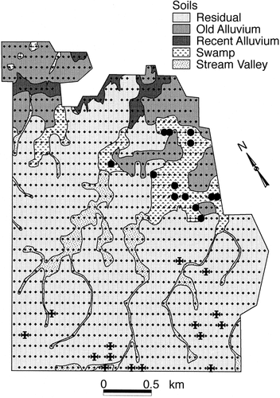

**Figure 5**

Open in figure viewer[PowerPoint](https://esajournals.onlinelibrary.wiley.com/action/downloadFigures?id=i0012-9658-80-8-29-f05&doi=10.1890%2F0012-9658%281999%29080%5B2662%3AEFATLS%5D2.0.CO%3B2)

The distribution of plots with *Pterocarpus officinalis* (Papilionoideae; solid circles) and *Quararibea ochrocalyx* (Bombacaceae; Maltese crosses). Compare with the distribution of points sampled shown in Fig. 1. All 13 plots with *P. officinalis* were located on Swamp soil; all 15 plots with *Q. ochrocalyx* were located on Residual soil.

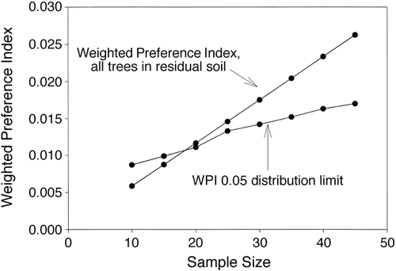

**Figure 6**

Open in figure viewer[PowerPoint](https://esajournals.onlinelibrary.wiley.com/action/downloadFigures?id=i0012-9658-80-8-29-f06&doi=10.1890%2F0012-9658%281999%29080%5B2662%3AEFATLS%5D2.0.CO%3B2)

The Weighted Preference Index (WPI) obtained if all individuals at different sample sizes occurred only in Residual soil, and the WPI randomization 95th percentile values. A sample of ∼18 individuals occurring only on Residual soil would be necessary to obtain a significant result with this data set.

This study clearly demonstrated that a major limitation to landscape analysis of tropical tree distributions is sample size. About half the species we sampled occurred as fewer than five individuals in the sample of 5127 trees, and 56 species (21%) occurred as singletons. This is typical for TRF inventories (Valencia et al. 1994), and for a community-wide sampling effort it is probably unavoidable. Larger sample sizes lead to greater statistical power (Zar 1996), or in this case, a greater ability to detect real edaphic biases in the mesoscale distribution of these species. The effect of increasing power with sample size was evident in the WPI analyses. The median sample size for the species detected with soil-biased distributions was 24, while the median for species not significantly related to soil types was 10 (Mann-Whitney *P*<sub>one-tail</sub> < 0.01).

One approach to increasing sample size per species in inventories is to increase plot size. This clearly increases the cost of sampling for a given number of plots, but it has another less obvious consequence. With the small plot size used in this study (diameter = 11.3 m), our edaphic characterizations of each plot were likely to apply to all trees in the plot. Indeed, at all levels of analysis we found evidence that tree distributions in these small plots were significantly related to the edaphic factors we measured at this scale. Increasing the plot size would have increased the within-plot edaphic heterogeneity. There is thus a trade-off between adequate edaphic characterization for each sampled tree and plot size (Lieberman et al. 1985*b*, Palmer and Dixon 1990). The fine-scale structure of edaphic heterogeneity over an entire old-growth TRF landscape has not yet been adequately characterized. However, results at several different spatial scales suggest that such heterogeneity is likely to be substantial in TRF (Richter and Babbar 1991, Johnston 1992, Tuomisto et al. 1995). When larger plots are used to study edaphic responses of TRF trees, the spatial structure of edaphic variance within these plots will need to be assessed.

### Other factors influencing landscape-scale distributions

We were unable to interpret the strong gradient in species’ distributions indicated by the second axis in the DCA analyses (which was the same gradient uncovered by the first partial DCA axis). In addition to soil type and topographic position, a variety of other factors can lead to such nonrandom spatial patterns of old-growth tree species over mesoscale TRF landscapes (D. B. Clark 1999). One such factor is anthropogenic impacts. Previously we found (Clark et al. 1995) that the edible palm *I. deltoidea* is missing from one section of the old-growth on Old Alluvium at La Selva. Multiple lines of evidence pointed to past human harvesting for heart of palm in this area. Other factors that could lead to nonrandom spatial distributions include stand disturbance history, local environmental heterogeneity not reflected in the existing soils map, mass effects (Shmida and Wilson 1985), and chance (Hubbell and Foster 1986*a*).

Fig. 5 illustrates a type of potentially nonrandom distribution that was not detectable by our analyses. All the plots with *Q. ochrocalyx* were restricted to the southern half of the Residual soil area. With our sample size of 798 Residual soil plots, this is unlikely to be a chance occurrence. The WPI randomization method, however, did not incorporate any spatial information other than soil type per se. Clearly there is scope to develop randomizations that include proximity to soil type boundaries, watercourses, successional forests, and other landscape elements likely to influence species’ distributions. Similarly, randomization approaches could be used to examine spatial relations among plots and within soil units.

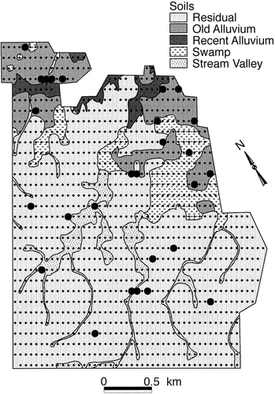

**Figure 7**

Open in figure viewer[PowerPoint](https://esajournals.onlinelibrary.wiley.com/action/downloadFigures?id=i0012-9658-80-8-29-f07&doi=10.1890%2F0012-9658%281999%29080%5B2662%3AEFATLS%5D2.0.CO%3B2)

The distribution of *Rauvolfia purpurascens* (Apocynaceae; solid circles) compare with the distribution of points sampled shown in Fig. 1.

### Future research directions

With the approaches discussed above, even with their limitations, we have shown that nonrandom spatial distributions of tree species are common over old-growth TRF landscapes. These spatial biases are observable even when extreme environments like swamps are excluded (see also Clark et al. 1998). However, the ecological origins of these nonrandom distributions are almost unstudied. How do these distributions arise? How are they maintained? At what life stage(s) do the different structuring processes operate? How important are factors such as inter- or intraspecific competition, disturbance history, mycorrhizae, and dispersal limitation?

One line for future research is to transplant species of different edaphic biases into different microenvironments in the field (cf. ter Steege 1994, Itoh 1995). The environmental complexity of field conditions can be minimized and studied by similar experiments under controlled conditions (Vitousek and Denslow 1987, Burslem et al. 1994, Veenendaal et al. 1996, Van der Heijden et al. 1998). However, translating the results of these experiments into an understanding of species’ mesoscale distributions will require understanding the distribution of edaphic factors at this spatial scale. To our knowledge there is no TRF landscape of this size (1–100 km<sup>2</sup>) for which there currently exists a spatially explicit database on quantitative soil chemistry at a scale sufficient to address the hypotheses raised by descriptive studies such as this one. Here we analyzed tree species distributions using highly aggregated soil categories based on the limited soils data currently available. It would be far preferable to base such a study on analyses of soil chemistry and texture for each sample plot. This combining of mesoscale vegetation sampling with quantitative soil analyses has yet to be done in old-growth TRF. We believe this approach is likely to show that many tropical tree species, more than the 30% shown here and possibly even the majority, are nonrandomly distributed in relation to edaphic factors when analyzed at the scale of moderately sized landscapes.

If the generality of edaphic structuring of tropical rain forest tree species is confirmed, it will have major implications for understanding the regeneration of TRF tree species over mesoscale landscapes. The basic requirement for edaphic structuring to arise is differential recruitment, related to edaphic conditions, among species. There are numerous theoretical routes to differential recruitment (Huston 1994), including differential growth, survival, and dispersal. In turn, these performance differences may or may not be mediated by inter- and/or intra-specific competition with plants of the same or different sizes. Understanding the mechanisms that lead to differential recruitment among edaphic conditions may lead to a substantially revised paradigm of tropical rain forest regeneration.

## Acknowledgments

We thank the Andrew W. Mellon Foundation for financial support. Leonel Campos Otoya and William Miranda Brenes walked hundreds of kilometers, endured torrential rains, and applied their considerable field skills to identify or voucher every tree in this study. We gratefully acknowledge their fundamental contribution to this work. Tropical ecologists stand on the shoulders of tropical systematists; this study would have been impossible without the collaboration of field botanists and museum taxonomists. We thank Orlando Vargas, Barry Hammel, Michael Grayum, Nelson Zamora, and the staffs of the Instituto Nacional de Biodiversidad and the Herbario Nacional de Costa Rica for patient and generous assistance. Nigel Pitman, Miles R. Silman, Michael Huston, and an anonymous referee provided usefully critical reviews. Logistic support was provided by the La Selva Biological Station of the Organization for Tropical Studies.

## Species name and authority, family name, voucher number, and location for the species discussed in this paper.

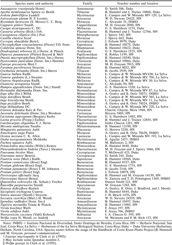

## Citing Literature

[Volume80, Issue8](https://esajournals.onlinelibrary.wiley.com/toc/19399170/1999/80/8)

December 1999

Pages 2662-2675

### Recommended

[Download PDF](https://esajournals.onlinelibrary.wiley.com/doi/pdf/10.1890/0012-9658%281999%29080%5B2662%3AEFATLS%5D2.0.CO%3B2)

back